# Digging for Gold

Perry Stephenson

2018-05-01

```r
# devtools::install_github("perrystephenson/goldminer")
library(tidyverse)
library(goldminer) # https://github.com/perrystephenson/goldminer
```

```r
config <- list()
params <- list()
env1 <- list()
env2 <- list()
config$rounds <- 1e6L # 1 million rounds
config$years <- 5
set.seed(12345)
```

# Approach

This analysis steps through several elements of the model, starting from the environment (which the operator of the mine cannot influence), through to some basic decision making strategies, robust modelled decisions, then some deep dives into specific decisions as guided by the data.

Accordingly, each of the environment variables will be modelled based on the provided parameters for the full five year period regardless of whether or not they are required in any individual simulation. Once the environment has been modelled, the impacts of decisions made by the business can be reasoned about without altering the modelled environment.

# Environment

### Gold Price

As specified, the initial price of gold in the first year is $1700, and the annual (absolute) change in the price is between -100 and 500, with an expected value of 100.

```r
params$gold_price_init <- 1700
params$gold_price_delta <- list(a = -100, b = 500, c = 100)
```

```r
env1$gold_price <- gen_gold_price(rounds = config$rounds,
                                  years = config$years,
                                  gold_price_init = params$gold_price_init,
                                  gold_price_delta = params$gold_price_delta)
```

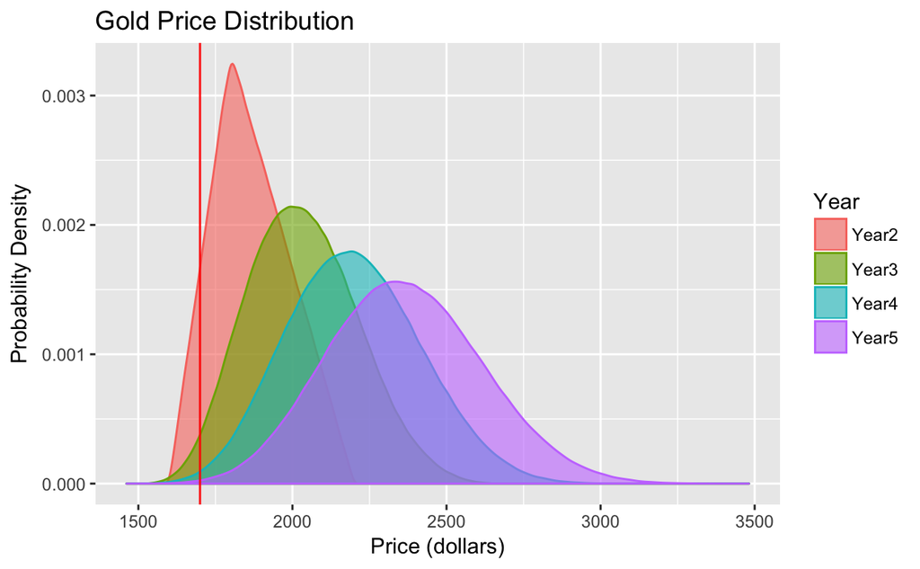

The distribution for Year 1 is marked by a single line at $1700, given that it is fixed by definition.

### Gold Production

As specified, the initial gold production in the first year is between 300 and 1400 ounces, with an expected value of 500 ounces. The production in each subsequent year is determined using the previous year’s output and multiplying the output by a value with a range of 0.8 to 1.8 with an expected value of 1.4.

```r
params$prod_init <- list(a = 300, b = 1400, c = 500)
params$prod_delta <- list(a = 0.8, b = 1.8, c = 1.4)
```

```r
env1$gold_prod <- gen_gold_prod(rounds = config$rounds,
                                years = config$years,
                                prod_init = params$prod_init,
                                prod_delta = params$prod_delta)
```

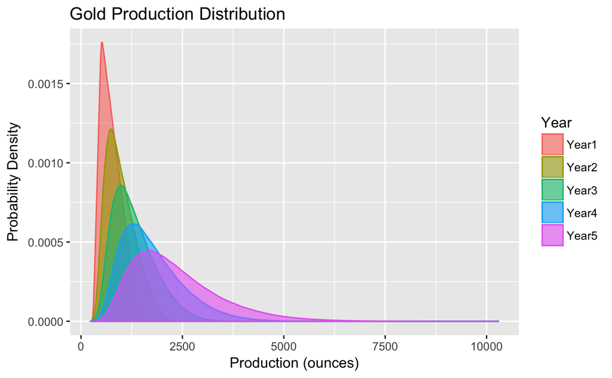

The production of gold is trending up over time, with the length of the positive tail increasing each year. The uncertainty also increases over time.

### Leased Mine Income Share

The company owns a second mine that they lease to a third party. The contract is structured in such a way that the income received includes a profit share component. The range of income from leasing this second mine is between 1 million and 3 million dollars, with an expected value of 2 million dollars.

Each subsequent year the income from the lease is determined by modifying the amount of the lease that was received in the **first year**. The income from the mine is in the range of -20% (i.e. 0.8x multiplier) and 45% (i.e. 1.45x multiplier) with an expected value of 10% (i.e. 1.1x multiplier).

```r
params$lease_profit_init <- list(a = 1000000, b = 3000000, c = 2000000)
params$lease_profit_delta <- list(a = 0.8, b = 1.45, c = 1.1)
```

```r
env1$lease_profit <- gen_lease_profit(rounds = config$rounds,
                                      years = config$years,
                                      profit_init = params$lease_profit_init,
                                      profit_delta = params$lease_profit_delta)
```

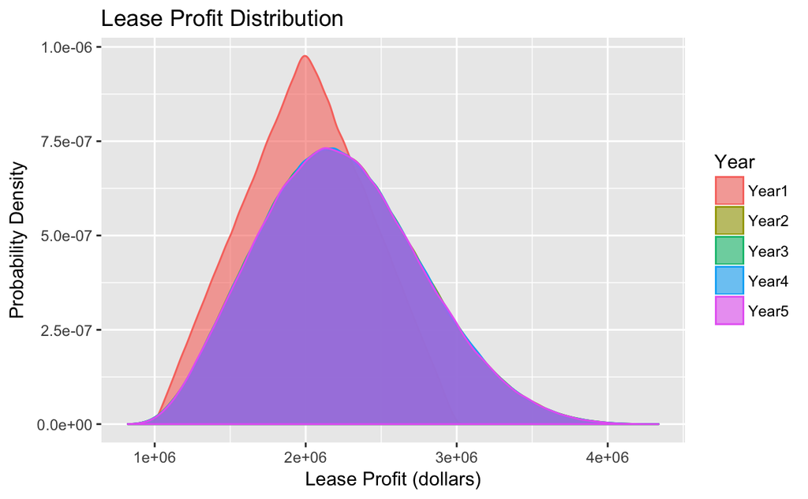

The probability distribution for each of the subsequent years is equal for all intents and purposes due to the fact that years 2 through 5 are based on year 1 rather than the previous year.

### Reputation Management

The company incurs reputation management costs while they own the second (leased) mine. These costs have a fixed component ($350,000 per year whilst the leased mine is still in operation) and a variable component ($2,500 per day) with an estimated range of 75 to 350 days per year (expected value 125 days).

```r
params$rep_mgmt_fixed <- 350000
params$rep_mgmt_rate <- 2500
params$rep_mgmt_var <- list(a = 75, b = 350, c = 125)
```

```r
env1$rep_mgmt <- gen_rep_mgmt(rounds = config$rounds,
                              years = config$years,
                              fixed = params$rep_mgmt_fixed,
                              rate = params$rep_mgmt_rate,
                              hours = params$rep_mgmt_var)
```

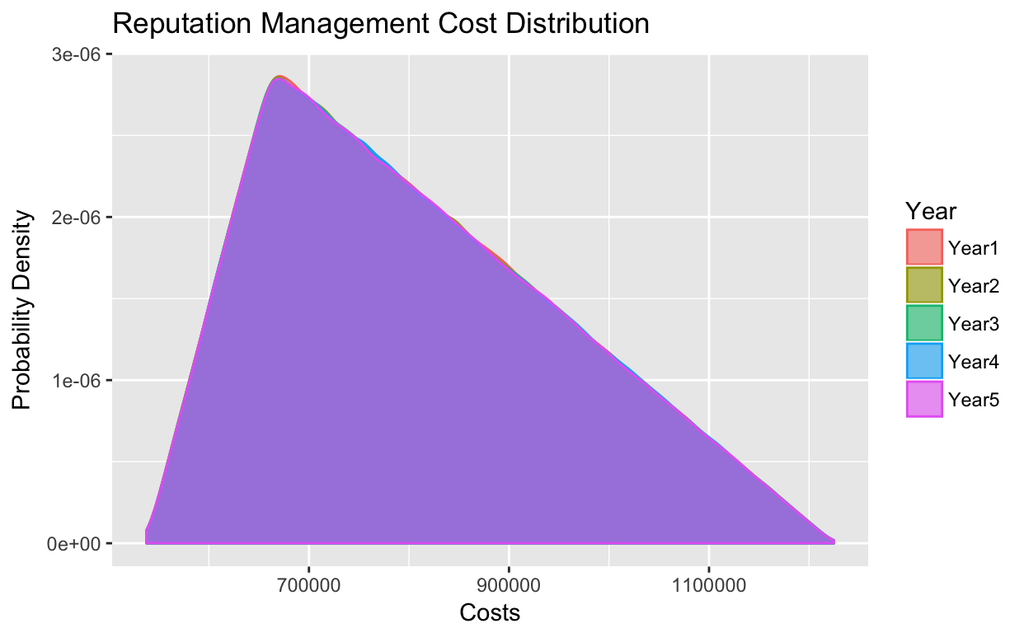

The probability distribution for each year of reputation management is equal for all intents and purposes due to the fact that the assumptions are independent from year to year.

### Mine Sale

The leased mine can be sold at the start of any year, and the price offered will be fixed as follows:

- Year 1 - $3,000,000
- Year 2 - $1,700,000
- Year 3 - $1,250,000
- Year 4 - $750,000
- Year 5 - $500,000

### Interest Rate

The interest rate is variable, but fixed for each 12 month period. The interest rate is not known in advance, but is understood to be in the range of 8% to 16% with an expected value of 12.75%.

```r
params$interest_rate_range <- list(a = 0.08, b = 0.16, c = 0.1275)
```

```r
env1$interest_rate <- gen_independent(rounds = config$rounds,
                                        years = config$years,
                                        t = params$interest_rate_range)
```

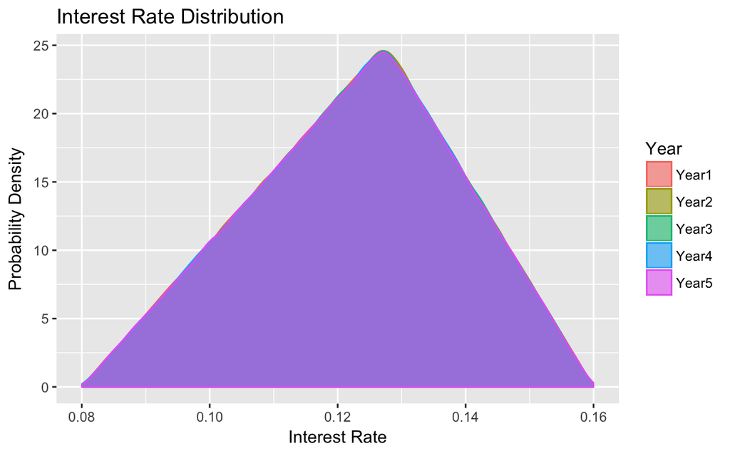

The probability distribution for the interest rate for each year is equal for all intents and purposes due to the fact that the assumptions are independent from year to year.

### Selling Cost

There is a cost associated with selling the gold such as transportation, broker fees, taxes and other charges. This is simplified for this model by taking a percentage of the total amount of money generated from the ore. This amount is initially in the range of 5% to 9.5% with an expected value of 7%.

The selling cost in each subsequent year is determined by applying a modifier to the previous year’s value. This modifier is a % change that is added to the previous year’s cost using the formula $prev * (1 + mod)$. The selling cost modifier is in the range -0.1 to 0.45, with an expected value of 0.2275.

```r
params$selling_cost_init <- list(a = 0.05, b = 0.095, c = 0.07)
params$selling_cost_delta <- list(a = -0.1, b = 0.45, c = 0.2275)
```

```r
env1$selling_cost <- gen_selling_rate(rounds = config$rounds,
                                      years = config$years,
                                      cost_init = params$selling_cost_init,
                                      cost_delta = params$selling_cost_delta)
```

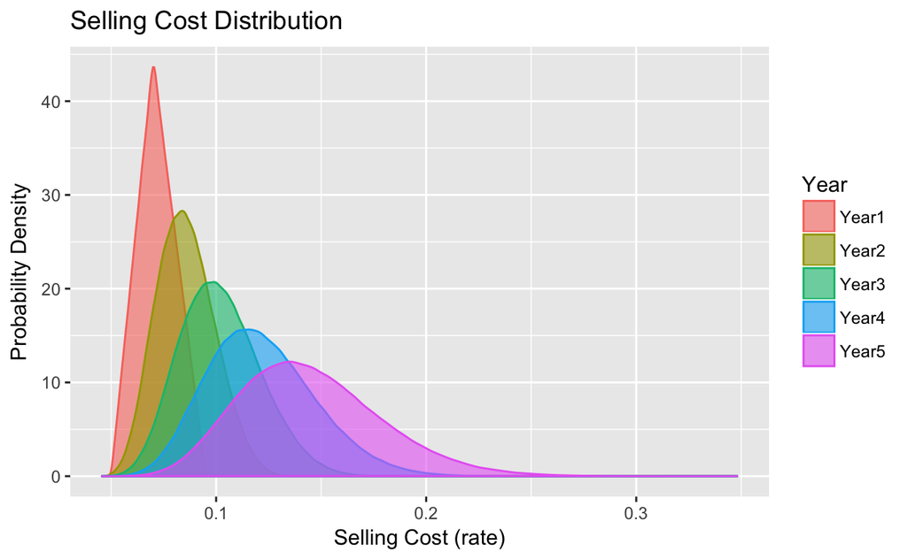

Selling costs are increasing over time, with increasing uncertainty.

### Equipment and Labour Costs

The mine requires fixed plant and employees to run. To simplify the model, all these costs are rolled up into the range of $2,000,000 to $5,500,000 with an expected value of $4,000,000. As equipment can break down and even need replacing this value is calculated each year and is independent of the previous year.

```r
params$equip_labour_range <- list(a = 2000000, b = 5500000, c = 4000000)
```

```r
env1$equip_labour <- gen_independent(rounds = config$rounds,
                                     years = config$years,
                                     t = params$equip_labour_range)
```

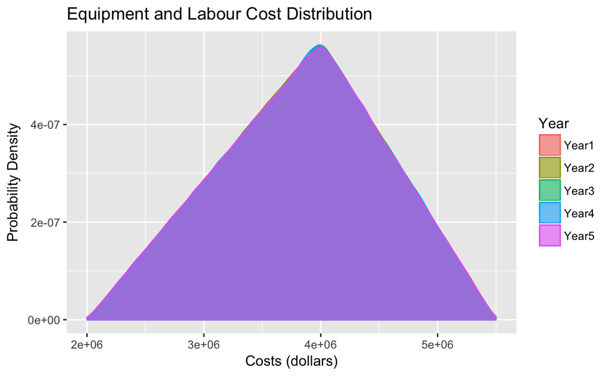

The probability distribution for the equipment and labour costs for each year is equal for all intents and purposes due to the fact that the assumptions are independent from year to year.

### Exploration

The majority of the exploration parameters are related to decision making rather than the environment, so they will be assessed in the next section of this report. As the second mine (if discovered) has a similar environment to the first mine, we can model it’s environment here using the same approach as above.

```r
# Start by copying the things that are equal for both mines
env2 <- env1[c("gold_price", "interest_rate")]
# Gold production in this mine is independent, but with the same parameters
env2$gold_prod <- gen_gold_prod(rounds = config$rounds,
                                years = config$years,
                                prod_init = params$prod_init,
                                prod_delta = params$prod_delta)
# Selling cost in this mine is independent, but with the same parameters
env2$selling_cost <- gen_selling_rate(rounds = config$rounds,
                                      years = config$years,
                                      cost_init = params$selling_cost_init,
                                      cost_delta = params$selling_cost_delta)
# Equipment and labour costs are half that of the other mine, but not
# independent. This means that they will depend on the simulation for mine 1.
env2$equip_labour <- env1$equip_labour / 2
```

For these values, the only one that is time-dependent is the gold production value, which effectively has a “time-shift” component based on the year the mine is found. We can deal with this when we need to. All other values are considered to be “fixed”, i.e. the costs for year 3 do not depend on the year in which the mine was discovered.

# Simulation and Decision Making

With the environment modelled appropriately, we can now commence simulation and evaluation of possible decisions.

### “Hands Off” Simulation

Firstly, let’s look at some base-case assumptions for a first pass simulation:

- No attempt to find the second mine
- No mine sale activity

```r
profit_naive <- do_nothing_profits(env1)
```

Overall, how are the total profits in each year distributed?

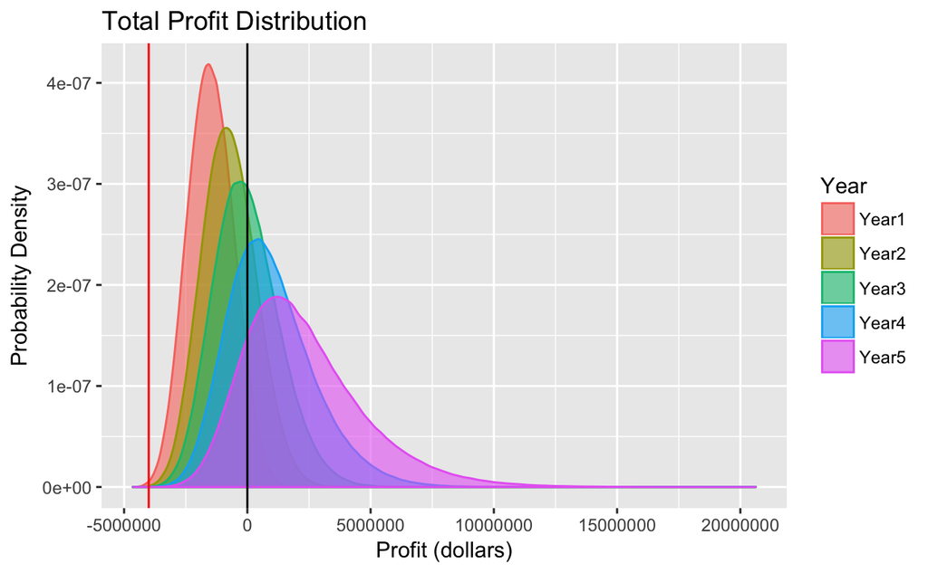

Without taking any action, the mining operation becomes more profitable over time. Unfortunately there are 962 cases where the profits are so far in the red that the bank will foreclose on the mine - and it only gets worse over the five year period:

```
       Status
Year    Foreclosure   Loss Profit
  Year1         962 941422  57616
  Year2      188763 719057  92180
  Year3      336761 481934 181305
  Year4      381393 302908 315699
  Year5      391297 151514 457189
```

Clearly there is some work to be done here!

### Controls Available

Each year, the operator of the mining company has the following options:

- Sell the leased mine (can only do this once)
- Explore for a third mine (can send 0-6 search parties, can only do this until found)
- Close the third mine (if it has been found)

This is significantly less control than a mining magnate would typically have over their investments.

These decisions are to be made annually - no decisions can be made during the year. This means that there are 5 decision points - one decision point before each year.

### Visibility

Whilst the owner has models to inform the team about the expected value of future environment variables (such as the price of gold, future production, etc) they cannot see the future. This means that “informed” decisions within individual simulations must be made according to the information available at the current time in that simulation.

### Priorities

The primary objective is to avoid foreclosure from the bank. In the case that foreclosure cannot be avoided, the objective is to minimise the chance of foreclosure. For the purpose of this analysis, foreclosure is considered to be *avoided* when less than 1% of simulations result in foreclosure.

The secondary objective is to maximise the median profit. Median has been selected because it is easy to reason about - there is a 50% chance that the profits will be at least this much.

The final objective is to minimise uncertainty, which will be measured using *standard deviation* of the final profit.

Decisions will be modelled in isolation where possible (for example when searching for a new mine) to reduce the complexity of the analysis and reduce the impact of componding assumptions in the model outputs.

### Naive approach to decisions

Looking simply at the decisions we can make prior to the start of the first year, there are two decisions to make:

1. Should the second mine be sold?
2. Should the search for a third mine be funded? (and how much?)

Based on the “do nothing” simulation above we know that the chance of foreclosure in the first year is negligible (0.1%), but the chance of foreclosure by the end of the 5 years is significant (39%). We should therefore try to understand how our decisions in the first year impact this 5-year foreclosure probability.

#### Where are the profits coming from?

The profit/loss performance of the first mine is summarised below:

```
       Status
Year      Loss Profit
  Year1 999977     23
  Year2 984540  15460
  Year3 878175 121825
  Year4 660140 339860
  Year5 413935 586065
```

Overall, the first mine is problematic. We’re really going to be leaning on the second and third mines to help us turn a profit here.

The profit/loss performance of the second mine is summarised below:

```
       Status
Year      Loss Profit
  Year1    528 999472
  Year2    510 999490
  Year3    493 999507
  Year4    513 999487
  Year5    464 999536
```

This is looking much healthier! We should still look at selling though, as the price in the first year is $3000000 which is far from negligible. We can look at the expected five-year profits and compare these to the sale price to get a feel about whether this is a good deal.

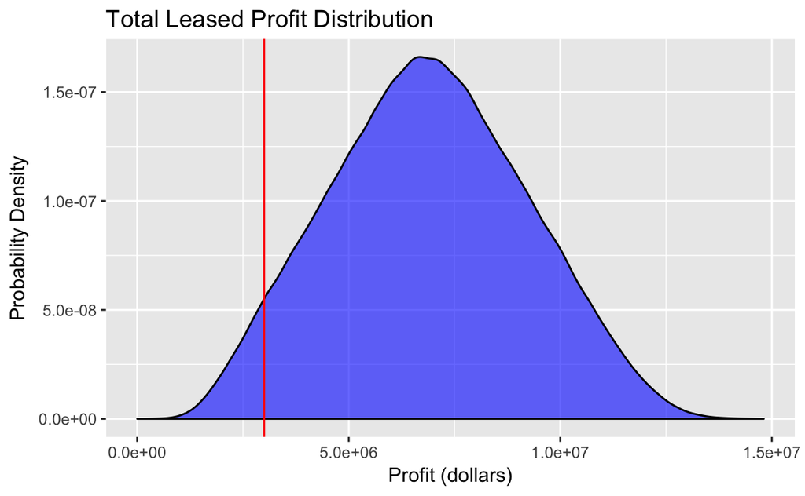

The sale price is in no way a fair price based on the expected returns from the second mine! However, the first objective is to avoid foreclosure, so we should analyse this option to see if it has a positive impact on the future foreclosure rate.

```r
sale_y1 <- profits_with_actions(env1, env2, params, sell_m2=1, find_m3=0)
```

```
       Status
Year    Foreclosure   Loss Profit
  Year1           0 362945 637055
  Year2       61664 826476 111860
  Year3      435500 473957  90543
  Year4      572046 278656 149298
  Year5      594768 154295 250937
```

Whilst this decision completely avoids the risk of foreclosure in the first year it makes the risk of foreclosure overall significantly worse due to the loss of the income from the second mine in subsequent years.

> It appears to be a terrible idea to sell the second mine prior to the first year of operation.

To assess whether it makes sense to search for the third mine at the start of the first year, we need to understand the potential profits from that mine if we were to find it.

```r
find_y1 <- profits_with_actions(env1, env2, params, sell_m2=0, find_m3=1)
```

```
       Status
Year    Foreclosure   Loss Profit
  Year1         962 941422  57616
  Year2      329251 604995  65754
  Year3      477801 373149 149050
  Year4      501367 187655 310978
  Year5      503629  51239 445132
```

This is a marginally better result than the sale of the second mine, but it’s still no better than the “do nothing case”.

> It does not appear to make sense to search for the second mine in year 1.

Finally, we should look at what happens when we sell the second mine and also find the third mine in the first year.

```r
both_y1 <- profits_with_actions(env1, env2, params, sell_m2=1, find_m3=1)
```

```
       Status
Year    Foreclosure   Loss Profit
  Year1           0 362945 637055
  Year2      196469 724211  79320
  Year3      557464 362592  79944
  Year4      620846 207312 171842
  Year5      626338  70334 303328
```

Just as I thought, it’s the worst of both worlds.

> You should not sell the second mine nor search for the third mine in the first year.

### Robust approach to decisions

If we assume that the third mine can be found on demand and for zero cost (i.e. best case), then there are 30 different combinations of the following options:

- Sell the second mine never, or in one of the 5 years
- Find the third mine never, or in one of the first 4 years

For each of these options, we will compare the number of simulated foreclosures in the final year, as minimising this number is the best way to achieve the first objective (avoid foreclosure).

```r
results <- tibble(
  sell_m2 = rep(NA, 30),
  find_m3 = rep(NA, 30),
  y5_foreclosure = rep(NA, 30)
)
for (i in 0:5) {
  for (j in 0:4) {
    idx <- i*5 + j + 1
    results[idx,"sell_m2"] <- i
    results[idx,"find_m3"] <- j
    profits <- profits_with_actions(env1, env2, params, sell_m2=i, find_m3=j)
    results[idx,"y5_foreclosure"] <-
      sum(profits$financial_position$Year5 == "Foreclosure")
  }
}
rm(i, j, idx)
results %>% arrange(y5_foreclosure)
```

| sell_m2 | find_m3 | y5_foreclosure |
| --- | --- | --- |
| 0 | 0 | 391297 |
| 0 | 4 | 405104 |
| 5 | 0 | 413083 |
| 5 | 4 | 433292 |
| 0 | 3 | 434685 |
| 5 | 3 | 455872 |
| 4 | 0 | 471344 |
| 0 | 2 | 473662 |
| 5 | 2 | 485566 |
| 4 | 4 | 494261 |

[output cut: 20 more lines]

Clearly, in the absence of government intervention, there is no reason to take any action at all, and purchasing the mine is a terrible idea in the first place.

# Making it Work

We can model these new assumptions, and see how they impact the analysis:

```r
env3 <- env1 # Make a copy
env4 <- env2 # Make a copy
env3$selling_cost <- env1$selling_cost / 2
env3$equip_labour <- env1$equip_labour / 2
env4$equip_labour <- env3$equip_labour / 2
profits_with_actions(env3, env4, params, sell_m2=0, find_m3=0)$financial_position %>%
  gather(Year, Status) %>%
  table()
```

```
       Status
Year    Foreclosure   Loss Profit
  Year1           0 251275 748725
  Year2           0 121905 878095
  Year3          21  58146 941833
  Year4         118  25495 974387
  Year5         187  10022 989791
```

Now we’re talking! Let’s take a look at what actions will help drive the chance of foreclosure to zero:

```r
results <- tibble(
  sell_m2 = rep(NA, 30),
  find_m3 = rep(NA, 30),
  y5_foreclosure = rep(NA, 30)
)
for (i in 0:5) {
  for (j in 0:4) {
    idx <- i*5 + j + 1
    results[idx,"sell_m2"] <- i
    results[idx,"find_m3"] <- j
    profits <- profits_with_actions(env3, env4, params, sell_m2=i, find_m3=j)
    results[idx,"y5_foreclosure"] <-
      sum(profits$financial_position$Year5 == "Foreclosure")
  }
}
rm(i, j, idx)
results %>% arrange(y5_foreclosure)
```

| sell_m2 | find_m3 | y5_foreclosure |
| --- | --- | --- |
| 0 | 1 | 70 |
| 1 | 1 | 74 |
| 5 | 1 | 76 |
| 4 | 1 | 77 |
| 0 | 2 | 91 |
| 3 | 1 | 91 |
| 5 | 2 | 97 |
| 1 | 2 | 103 |
| 0 | 3 | 116 |
| 5 | 3 | 118 |

[output cut: 20 more lines]

There is a bit of variability here, ranging from less 0.01% foreclosure to almost 0.1% foreclosure. It’s definitely unlikely! There is now also a strong signal that finding the second mine as soon as possible is a good thing to do. We should start to incorporate the cost of the search - starting with 6 search parties to check everything is working.

```r
params$search_price <- list(   0, 2e5L, 5e5L, 9e5L, 13e5L, 17e5L)
params$search_prob  <- list(0.09, 0.28, 0.39, 0.48,  0.56,  0.62)
profits_with_search(env3, env4, params, sell_m2=0, search=6)$financial_position %>%
  gather(Year, Status) %>%
  table()
```

```
       Status
Year    Foreclosure   Loss Profit
  Year1           0 959412  40588
  Year2       28620 596213 375167
  Year3       49591 283945 666464
  Year4       52288 105181 842531
  Year5       52341  21699 925960
```

It looks like we have some balancing to do! Let’s look at all of the options together.

```r
results <- tibble(
  sell_m2         = rep(NA, 36),
  search_strength = rep(NA, 36),
  y5_foreclosure  = rep(NA, 36)
)
for (i in 0:5) {
  for (j in 1:6) {
    idx <- i*6 + j
    results[idx,"sell_m2"] <- i
    results[idx,"search_strength"] <- j
    profits <- profits_with_search(env3, env4, params, sell_m2=i, search=j)
    results[idx,"y5_foreclosure"] <-
      sum(profits$financial_position$Year5 == "Foreclosure")
  }
}
rm(i, j, idx)
results %>% arrange(y5_foreclosure)
```

| sell_m2 | search_strength | y5_foreclosure |
| --- | --- | --- |
| 5 | 1 | 190 |
| 0 | 1 | 194 |
| 1 | 1 | 244 |
| 4 | 1 | 270 |
| 3 | 1 | 364 |
| 0 | 2 | 579 |
| 5 | 2 | 612 |
| 2 | 1 | 731 |
| 4 | 2 | 834 |
| 1 | 2 | 878 |

[output cut: 26 more lines]

From this analysis it is very clear that searching is worthwhile, but that a single search party is best when considering the risk of foreclosure.

Finally, let’s consider how profits are impacted with each of these decisions.

```r
results <- tibble(
  sell_m2         = rep(NA, 36),
  search_strength = rep(NA, 36),
  y5_foreclosure  = rep(NA, 36),
  median_cash_y5  = rep(NA, 36)
)
for (i in 0:5) {
  for (j in 1:6) {
    idx <- i*6 + j
    results[idx,"sell_m2"] <- i
    results[idx,"search_strength"] <- j
    profits <- profits_with_search(env3, env4, params, sell_m2=i, search=j)
    results[idx,"y5_foreclosure"] <-
      sum(profits$financial_position$Year5 == "Foreclosure")
    results[idx, "median_cash_y5"] <- median(profits$cash$Year5[[1]])
  }
}
rm(i, j, idx)
results %>% arrange(desc(median_cash_y5))
```

| sell_m2 | search_strength | y5_foreclosure | median_cash_y5 |
| --- | --- | --- | --- |
| 0 | 2 | 565 | 12190481 |
| 0 | 1 | 177 | 12022630 |
| 0 | 3 | 2121 | 11798711 |
| 0 | 4 | 8759 | 11221264 |
| 5 | 2 | 604 | 11220165 |
| 5 | 1 | 194 | 11049313 |
| 5 | 3 | 2273 | 10831820 |
| 0 | 5 | 23875 | 10715088 |
| 5 | 4 | 8970 | 10251675 |
| 0 | 6 | 52266 | 10206118 |

[output cut: 26 more lines]

This is great news - there is a really clear strategy emerging here:

1. Pressure the government for tax breaks, and hire cheap foreign workers. This is essential, and the mine should not be purchased without these conditions.
2. Do not sell mine 2, and if you do have to sell it (for example if you have cashflow issues), sell it as late as possible.
3. Send a small search party of only 1 or 2 groups

# Reproducability